# Week 3 - ggplot2 intro

Brian Stock

26 January, 2017

# 1 Pull from the course Github

This is an intermediate R course adopted from a [Harvard tutorial](http://tutorials.iq.harvard.edu/R/Rgraphics/Rgraphics.html)

- Assumes working knowledge of R
- Relatively fast-paced
- Focus is on `ggplot2` graphics–other packages will not be covered

# 2 Starting at the end

# 3 What is `ggplot2`?

Popular alternative to “base” R graphics, especially for publication-quality plots.

## 3.1 Advantages of ggplot2

- consistent underlying ‘grammar of graphics’ (Wilkinson 2005)
- plot specification at a high level of abstraction
- very flexible
- theme system for polishing plot appearance
- mature and complete graphics system
- many users, active mailing list

### 3.1.1 Example: way less code for complex plot

From http://varianceexplained.org/r/why-I-use-ggplot2/

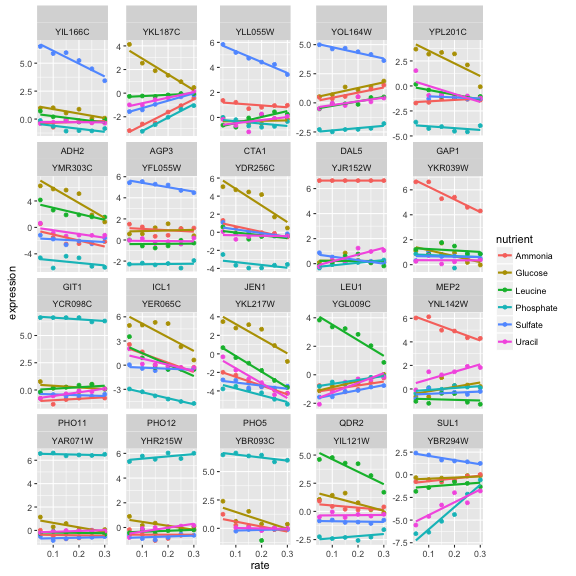

```r
ggplot(top_data, aes(rate, expression, color = nutrient)) +
    geom_point() +
    geom_smooth(method = "lm", se = FALSE) +
    facet_wrap(~name + systematic_name, scales = "free_y")
```

Now create the same using base graphics:

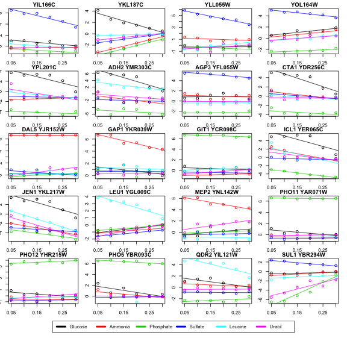

```r
par(mar = c(1.5, 1.5, 1.5, 1.5))

colors <- 1:6
names(colors) <- unique(top_data$nutrient)

# legend approach from http://stackoverflow.com/a/10391001/712603
m <- matrix(c(1:20, 21, 21, 21, 21), nrow = 6, ncol = 4, byrow = TRUE)
layout(mat = m, heights = c(.18, .18, .18, .18, .18, .1))

top_data$combined <- paste(top_data$name, top_data$systematic_name)
for (gene in unique(top_data$combined)) {
    sub_data <- filter(top_data, combined == gene)
    plot(expression ~ rate, sub_data, col = colors[sub_data$nutrient], main = gene)
    for (n in unique(sub_data$nutrient)) {
        m <- lm(expression ~ rate, filter(sub_data, nutrient == n))
        if (!is.na(m$coefficients[2])) {
            abline(m, col = colors[n])
        }
    }
}

# create a new plot for legend
plot(1, type = "n", axes = FALSE, xlab = "", ylab = "")
legend("top", names(colors), col = colors, horiz = TRUE, lwd = 4)
```

## 3.2 Other plotting packages can be better in certain cases:

- quick exploratory plots can be simpler with base graphics

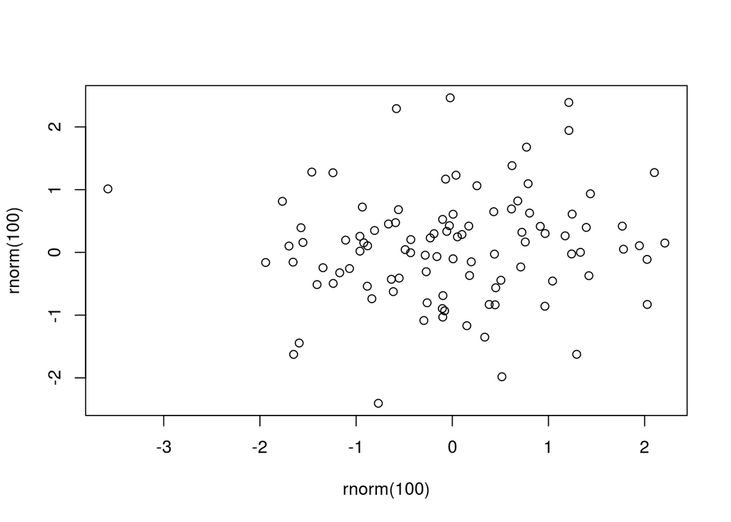

```r
plot(rnorm(100),rnorm(100))
```

- 3-d plots (`rgl` package, Week 8)
- Interactive graphics (see `ggvis` and `gganimate` packages, or Shiny for GUI, Weeks 8 and 9)
- Graph-theory type graphs (nodes/edges layout, see `igraph` package)

# 4 What Is this *Grammar Of Graphics*?

Basic idea: independently specify plot building blocks and combine them to create just about any kind of graphical display you want. Building blocks of a graph include:

- data
- aesthetic mapping
- geometric object
- statistical transformations
- scales
- coordinate system
- position adjustments
- faceting

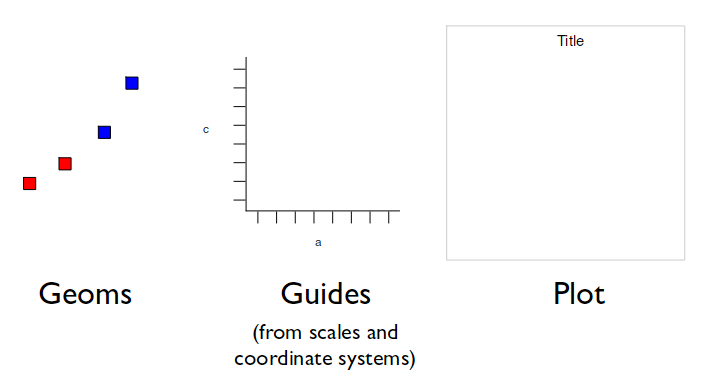

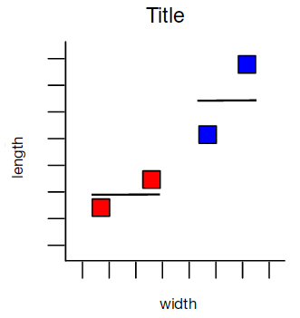

# 5 Example Data: `Housing prices`

Data from https://www.lincolninst.edu/subcenters/land-values/land-prices-by-state.asp

```r
housing <- read.csv("landdata-states.csv")
head(housing[1:5])
```

```
##   State region  Date Home.Value Structure.Cost
## 1    AK   West 20101     224952         160599
## 2    AK   West 20102     225511         160252
## 3    AK   West 20093     225820         163791
## 4    AK   West 20094     224994         161787
## 5    AK   West 20074     234590         155400
## 6    AK   West 20081     233714         157458
```

```r
housing$Year <- as.numeric(substr(housing$Date, 1, 4))
housing$Qrtr <- as.numeric(substr(housing$Date, 5, 5))
housing$Date <- housing$Year + housing$Qrtr/4
```

## 5.1 Compared to base graphics, `ggplot2`:

- is more verbose for simple / canned graphics
- is less verbose for complex / custom graphics
- does not have methods (data should always be in a `data.frame`)
- uses a different system for adding plot elements

### 5.1.1 Base graphics histogram example:

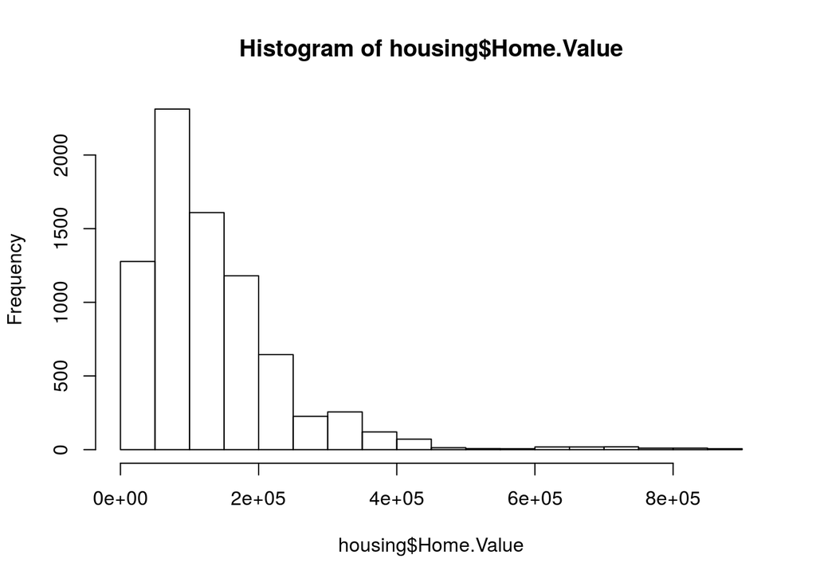

```r
hist(housing$Home.Value)
```

### 5.1.2 `ggplot2` histogram example:

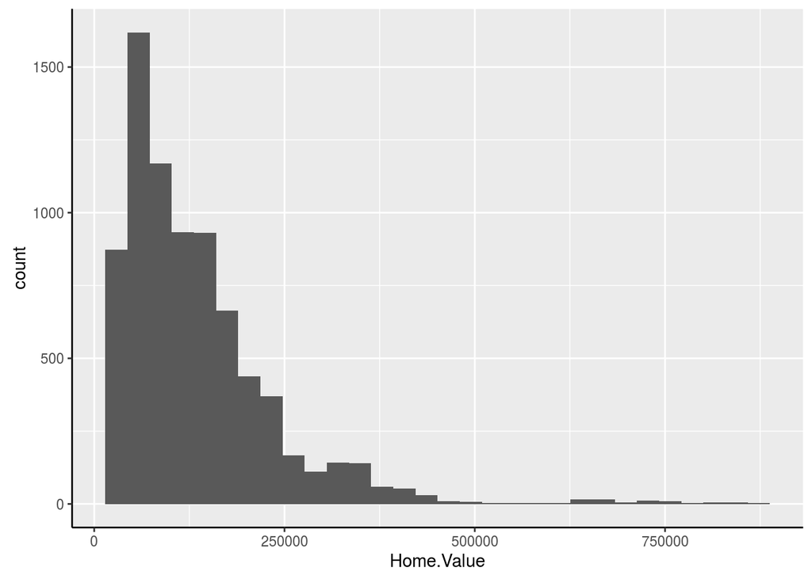

```r
library(ggplot2)
ggplot(housing, aes(x = Home.Value)) +
  geom_histogram()
```

Base wins for simple plot!

### 5.1.3 Base colored scatter plot example:

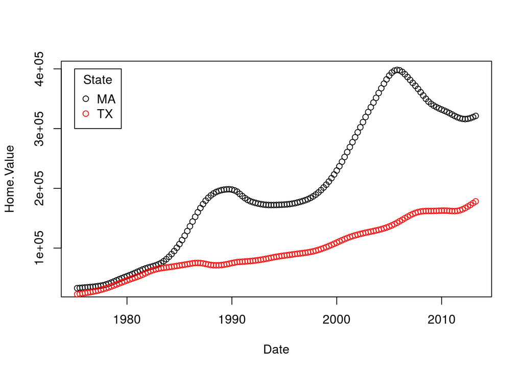

```r
plot(Home.Value ~ Date,
     data=subset(housing, State == "MA"))
points(Home.Value ~ Date, col="red",
       data=subset(housing, State == "TX"))
legend(1975, 400000,
       c("MA", "TX"), title="State",
       col=c("black", "red"),
       pch=c(1, 1))
```

### 5.1.4 `ggplot2` colored scatter plot example:

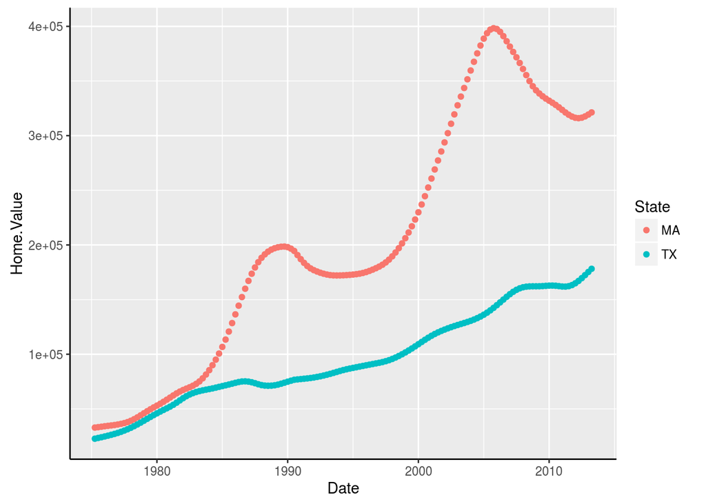

```r
ggplot(subset(housing, State %in% c("MA", "TX")),
       aes(x=Date,
           y=Home.Value,
           color=State))+
  geom_point()
```

ggplot2 wins for more complex plot!

# 6 Geometric Objects And Aesthetics

## 6.1 Aesthetic Mapping

In ggplot land **aesthetic** means *something you can see*. Examples include:

- position (i.e., on the x and y axes)
- color (“outside” color)
- fill (“inside” color)
- shape (of points)
- linetype
- size

Each type of geom accepts only a subset of all aesthetics–refer to the geom help pages to see what mappings each geom accepts. Aesthetic mappings are set with the `aes()` function.

## 6.2 Geometic Objects (`geom`)

Geometric objects are the actual marks we put on a plot. Examples include:

- points (`geom_point`, for scatter plots, dot plots, etc)
- lines (`geom_line`, for time series, trend lines, etc)
- boxplot (`geom_boxplot`, for …duh, boxplots)

A plot must have at least one geom; there is no upper limit. You can add a geom to a plot using the `+` operator

You can get a list of available geometric objects using the code below:

```r
help.search("geom_", package = "ggplot2")
```

Or simply type `geom_<tab>` in RStudio to see a list of functions starting with `geom_`

## 6.3 Points (Scatterplot)

Now that we know about geometric objects and aesthetic mapping, we can make a ggplot. `geom_point` requires mappings for x and y, the `aes()`. All others are optional.

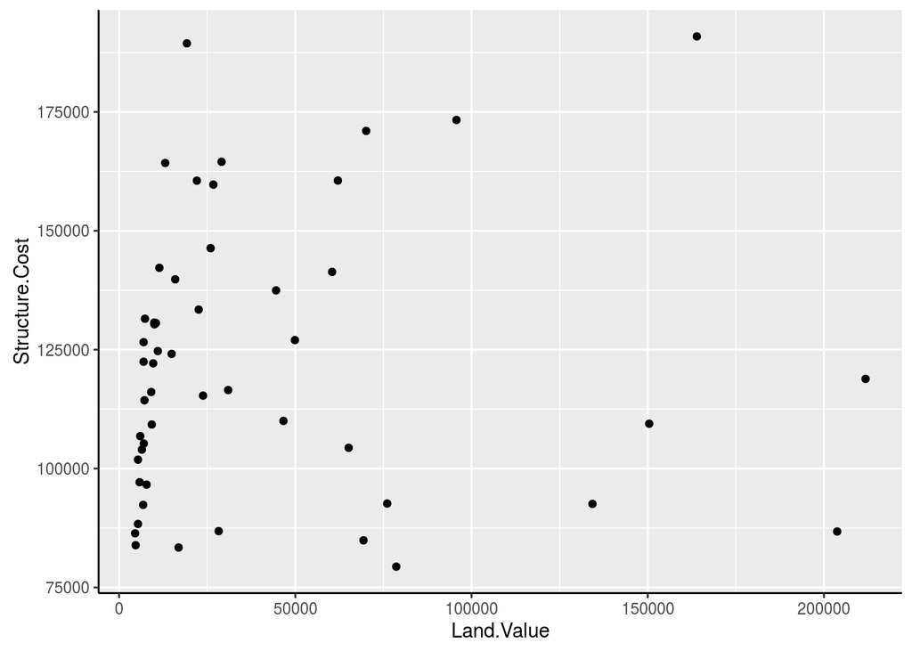

```r
hp2001Q1 <- subset(housing, Date == 2001.25)
ggplot(hp2001Q1,
       aes(y = Structure.Cost, x = Land.Value)) +
  geom_point()
```

Same thing but log transform the Land Values:

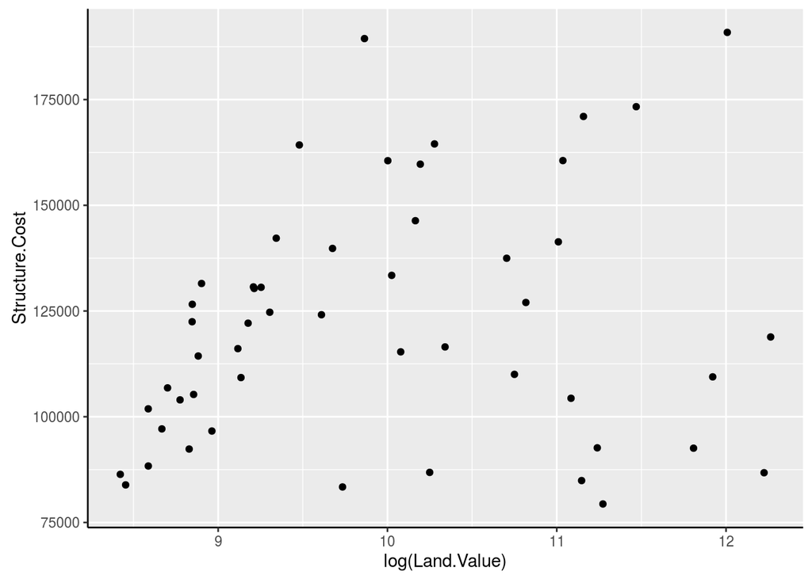

```r
ggplot(hp2001Q1,
       aes(y = Structure.Cost, x = log(Land.Value))) +
  geom_point()
```

## 6.4 Lines (Prediction Line)

A plot constructed with `ggplot` can have more than one geom. In that case the mappings established in the `ggplot()` call are plot defaults that can be added to or overridden. Our plot could use a regression line:

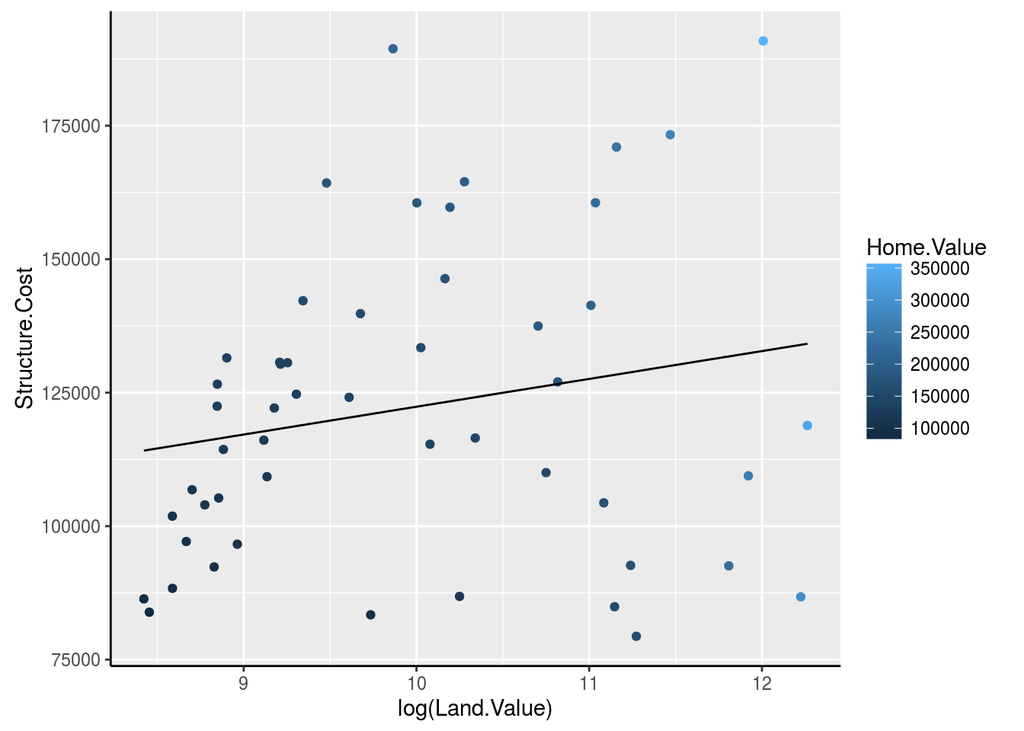

```r
hp2001Q1$pred.SC <- predict(lm(Structure.Cost ~ log(Land.Value), data = hp2001Q1))

p1 <- ggplot(hp2001Q1, aes(x = log(Land.Value), y = Structure.Cost))

p1 + geom_point(aes(color = Home.Value)) +
  geom_line(aes(y = pred.SC))
```

## 6.5 Smoothers

Not all geometric objects are simple shapes—`geom_smooth` includes a line and a ribbon. Hooray for confidence intervals!

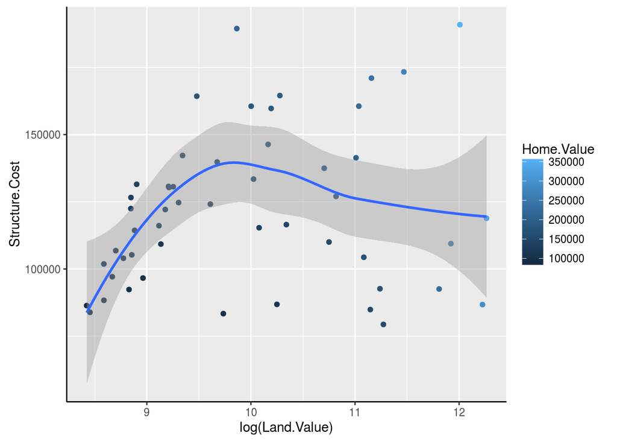

```r
p1 +
  geom_point(aes(color = Home.Value)) +
  geom_smooth()
```

## 6.6 Text (Label Points)

Each `geom` accepts a particualar set of mappings. For example, `geom_text()` accepts a `labels` mapping.

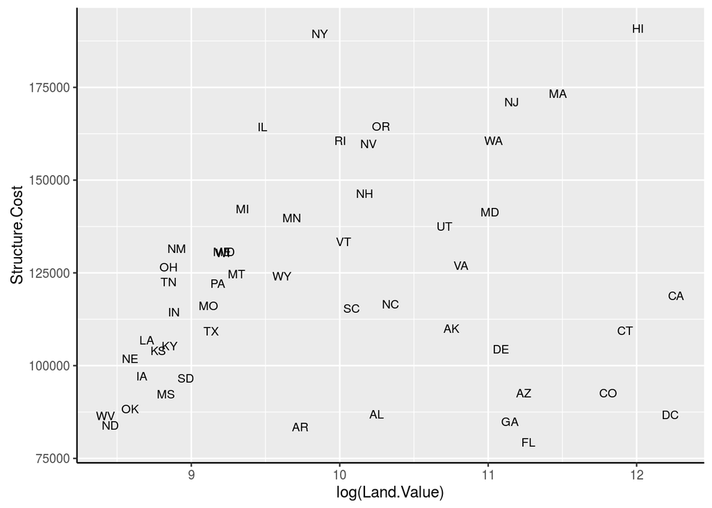

```r
p1 +
  geom_text(aes(label=State), size = 3)
```

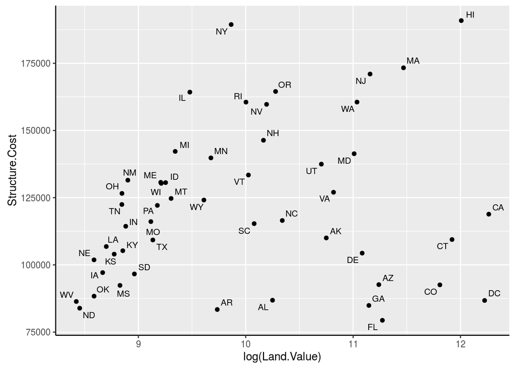

```r
## install.packages("ggrepel")
library("ggrepel")
p1 +
  geom_point() +
  geom_text_repel(aes(label=State), size = 3)
```

## 6.7 Aesthetic Mapping VS Assignment

Note that *variables* are mapped to aesthetics with the `aes()` function, while *fixed* aesthetics (i.e. want to apply to ALL points) are set outside the `aes()` call. This sometimes leads to confusion, as in this example:

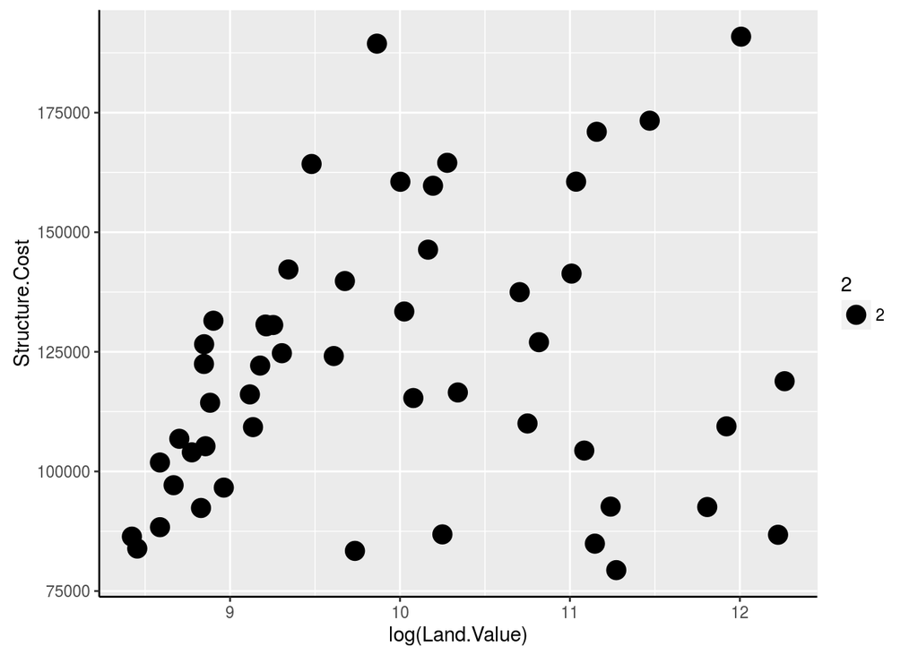

```r
p1 +
  geom_point(aes(size = 2))# incorrect! 2 is not a variable
```

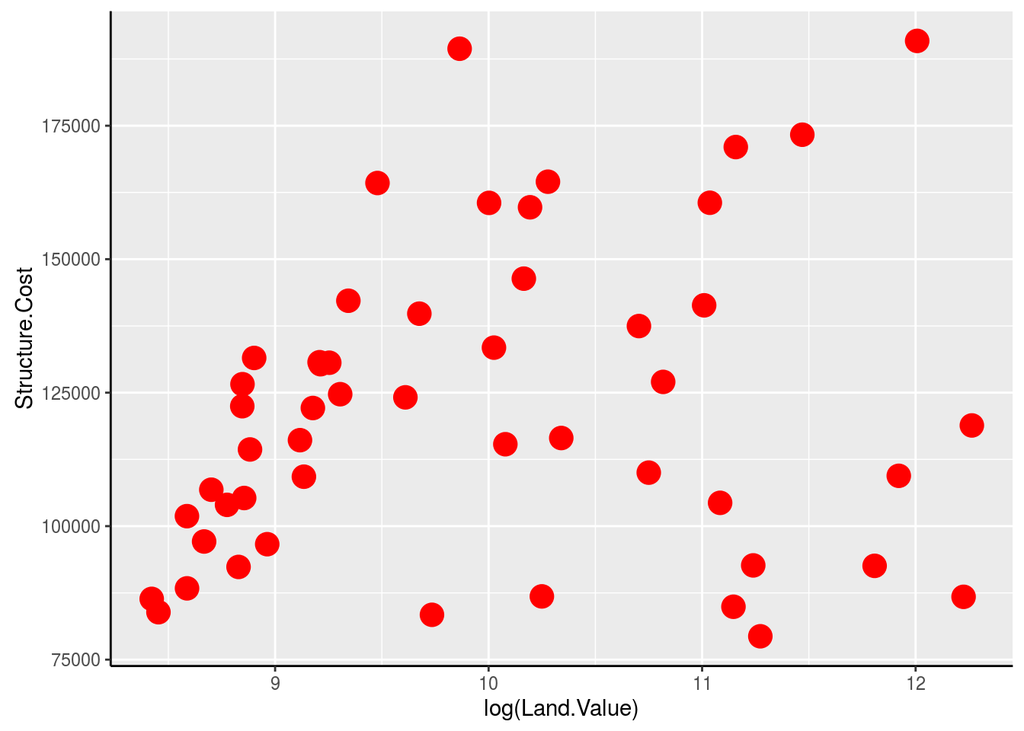

```r
p1 +
  geom_point(size = 5, color="red") # correct, not in aes()
```

## 6.8 Mapping Variables To Other Aesthetics

Other aesthetics are mapped in the same way as x and y in the previous example.

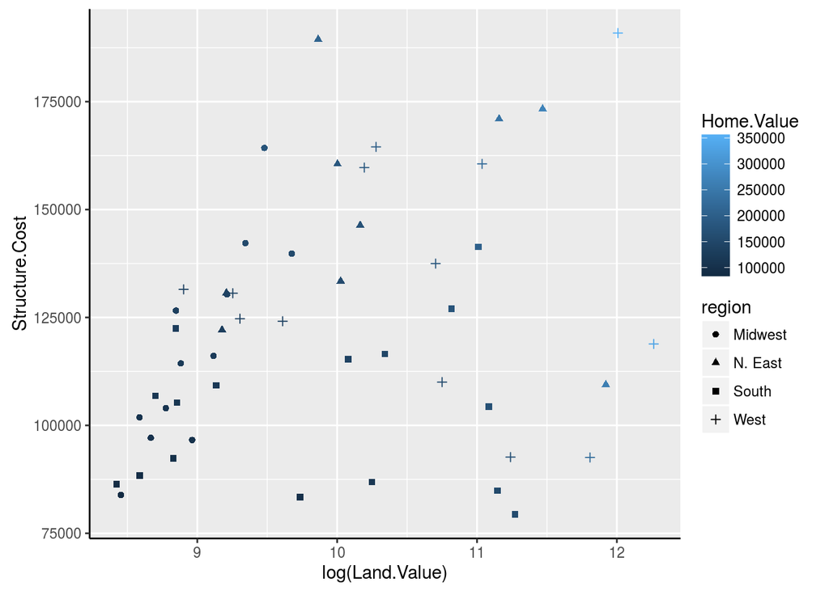

```r
p1 +
  geom_point(aes(color=Home.Value, shape = region))
```

# 7 Now you try!

Example data consist of *Human Development Index* and *Corruption Perception Index* scores for several countries. The data is in the `EconomistData.csv` file. Read it in with:

```r
dat <- read.csv("EconomistData.csv") # Have to be in correct working directory
head(dat)
```

```
##   X     Country HDI.Rank   HDI CPI            Region
## 1 1 Afghanistan      172 0.398 1.5      Asia Pacific
## 2 2     Albania       70 0.739 3.1 East EU Cemt Asia
## 3 3     Algeria       96 0.698 2.9              MENA
## 4 4      Angola      148 0.486 2.0               SSA
## 5 5   Argentina       45 0.797 3.0          Americas
## 6 6     Armenia       86 0.716 2.6 East EU Cemt Asia
```

Try to make the following plots. I hid the code - no cheating! If you want to see it, look in the `.Rmd` file.

1. Create a scatter plot with CPI on the x axis and HDI on the y axis.
2. Color the points in the previous plot blue.
3. Color the points in the previous plot according to *Region*.
4. Create boxplots of CPI by Region
5. Overlay points on top of the box plots and save to file

## 7.1 Scatter plot with CPI on the x axis and HDI on the y axis

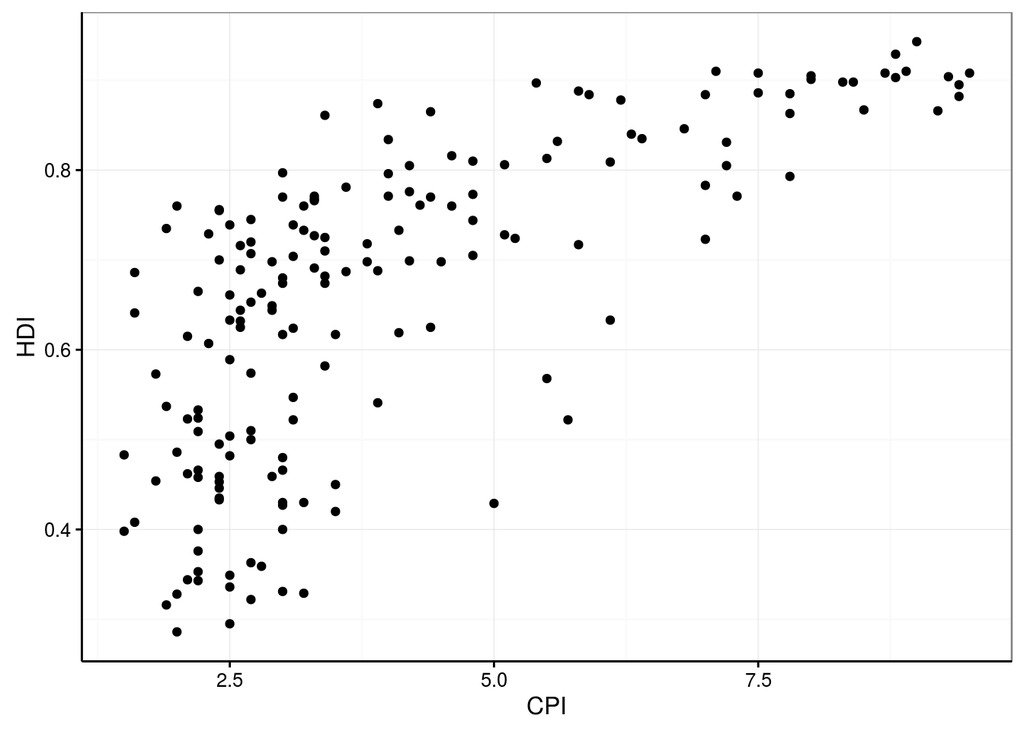

## 7.2 Color the points blue

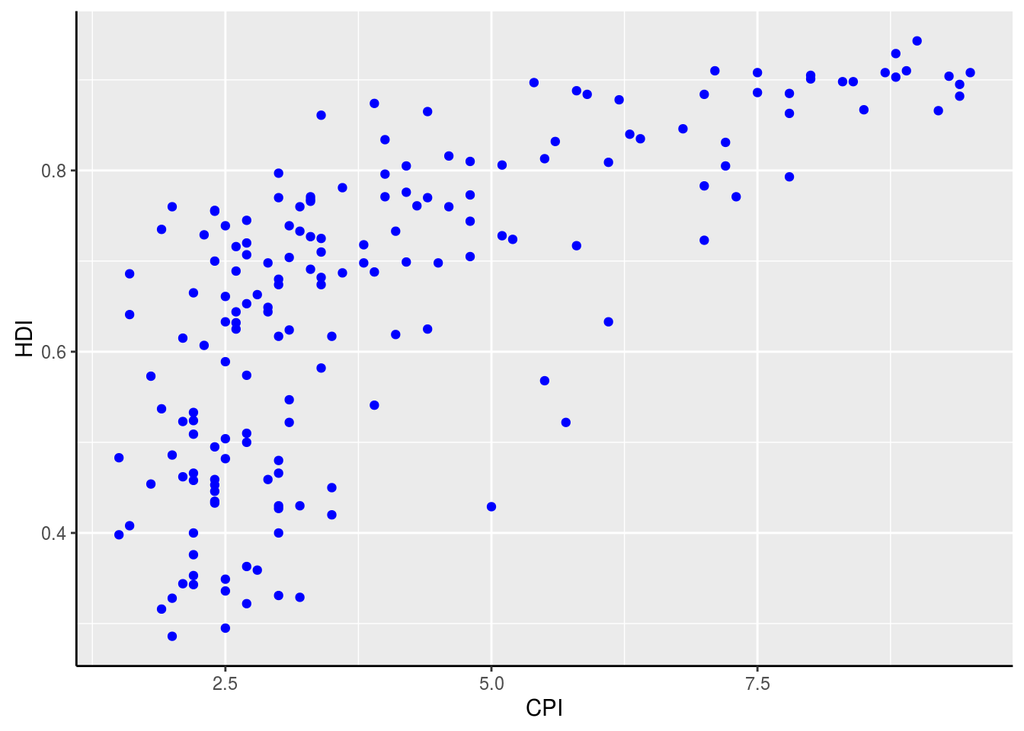

## 7.3 Color according to region

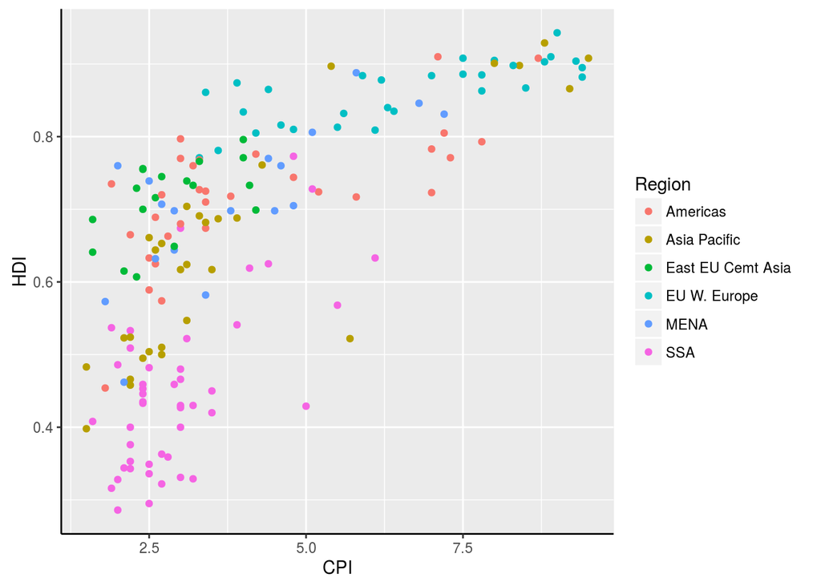

## 7.4 Boxplots of CPI by region

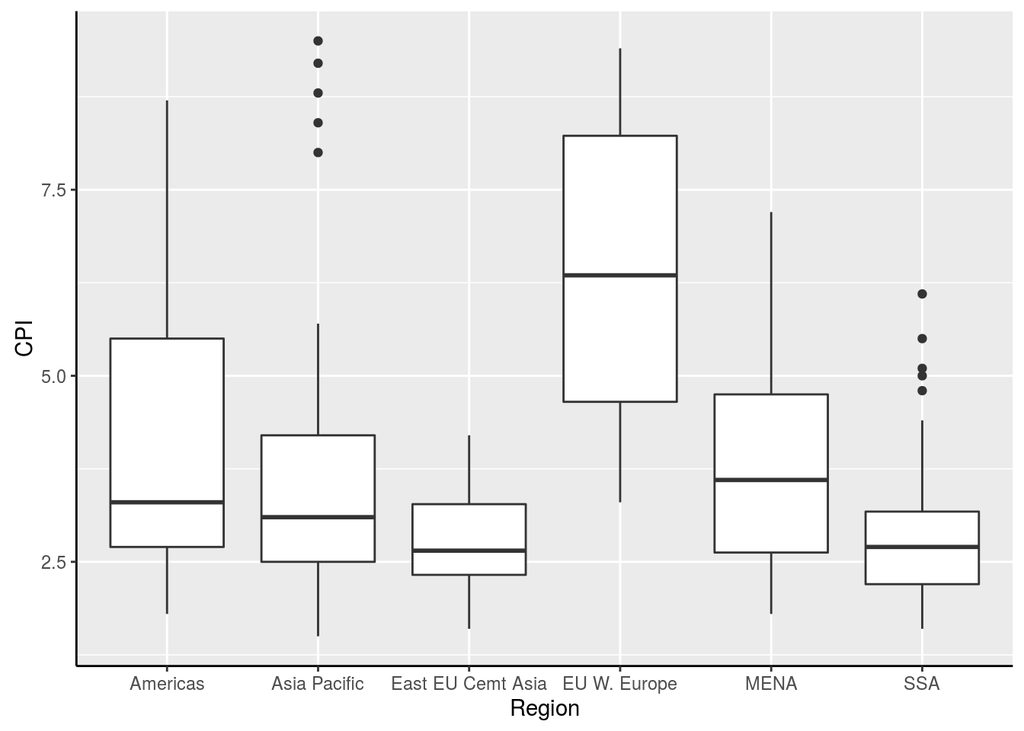

## 7.5 Overlay points on top of boxplots and save to file

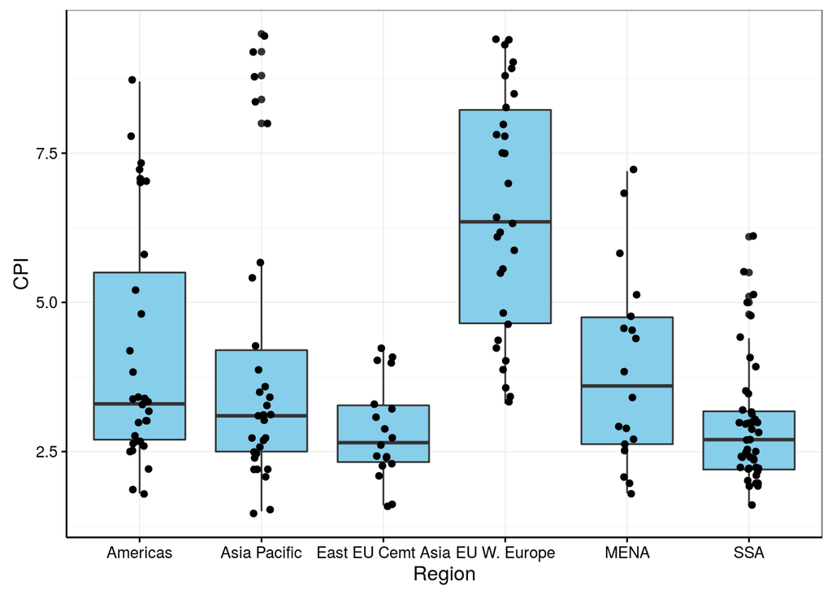

# 8 Resources

- Basis for this lesson 1: [Harvard tutorial](http://tutorials.iq.harvard.edu/R/Rgraphics/Rgraphics.html)
- Basis for this lesson 2: [Hadley slides](http://ggplot2.org/resources/2007-vanderbilt.pdf)
- [Hadley book PDF](http://roger.ucsd.edu/record=b6914994~S9)
- [Hadley slides on ggplot2 motivation and examples](http://ggplot2.org/resources/2007-past-present-future.pdf)
- [Doesn’t like ggplot so much](http://simplystatistics.org/2016/02/11/why-i-dont-use-ggplot2/)
- [Response to above, pro-ggplot](http://varianceexplained.org/r/why-I-use-ggplot2/)
- [Reasons to use ggplot system](https://mandymejia.wordpress.com/2013/11/13/10-reasons-to-switch-to-ggplot-7/)